# Demonstration of the `PUMP` package

# Case study

We illustrate our package with a published RCT evaluation of a secondary school model called Diplomas Now. The Diplomas Now model is designed to increase high school graduation rates and post-secondary readiness. valuators evaluated whether the program was effective by conducting a RCT comparing schools who implemented the model to versus business as usual. We refer to this example to illustrate key concepts and to illustrate the application of the PUMP package.

The Diplomas Now model, created by three national organizations, Talent Development, City Year, and Communities In Schools, targets underfunded urban middle and high schools with many students who are not performing well academically. The model is designed to be robust and intense enough to transform or turn around high-poverty and high-needs middle grade and high schools attended by many students who fall off the path to high school graduation. Diplomas Now, with MDRC as a partner, was one of the first validation grants awarded as part of the Investing in Innovation (i3) competition administered by the federal Department of Education. We follow the general design of the Diplomas Now evaluation, conducted by MDRC. The RCT contains three levels (students within schools within districts) with random assignment at level 2 (schools). The initial evaluation, which included two cohorts of schools with each cohort implementing for two years (2011-2013 for Cohort 1 and 2012-2014 for Cohort 2), included 62 secondary schools (both middle and high schools) in 11 school districts that agreed to participate. Schools in the active treatment group were assigned to implement the Diplomas Now model, while the schools in the control group continued their existing school programs or implemented other reform strategies of their choosing (See @DNREPORT.)

The evaluation focused on three categories of outcomes (Attendance, Behavior, Course performance, called the “ABC’s”, with multiple measures for each category), along with overall ABC composite measures of whether a student is above given thresholds on all three categories. This grouping constitutes 12 total outcomes of interest. Evaluating each of the 12 outcomes independently would not be good practice, as the chance of a spurious finding is not well controlled. The authors of the MDRC report pre-identified three of these outcomes as *primary* outcomes before the start of the study in order to protect against such spurious findings that might arise from conducting multiple hypothesis tests without adjustment. We, by contrast, use this example to illustrate what could be done if there was uncertainty as to what should be the primary outcome. In particular, we illustrate how to conduct a power analysis to plan a study where one uses multiple testing adjustment, rather than predesignation, to account for the multiple outcome problem.

Due to the grouped nature of the outcomes, we elect to do a power analysis separately for each outcome group (mimicking the three chosen outcomes of the original study) to control family-wise error rather than overall error. We would then adjust for the number of outcomes within each group independently. We note that there are different guidelines for when to adjust for multiple outcomes in education studies. This paper would apply to either case. In this paper, the word “outcome” refers to either a single outcome or an outcome domain, and the paper focuses on any situation in which an analyst would apply adjustments to account for multiple outcomes.] We do not provide recommendations for which guidelines to follow when investigating impacts on multiple outcomes. Rather, we address the fact that researchers across many domains are increasingly applying MTPs and therefore need estimate power, MDES and sample size requirements. For illustration purposes, we focus on an alternative approach in the Diplomas Now study on assessing impacts of all 12 outcomes and applying MTPs to protect against the potential for spurious findings.

# Package illustration

In this section, we illustrate how to use the PUMP package, using our example motivated by the Diplomas Now study. Given the study’s design, we ask a natural initial question: What size of impact could we reasonably detect after using an MTP to adjust $p$-values to account for our multiple outcomes?

## Establishing needed design parameters

To conduct power, MDES, and sample size calculations, we first must specify the design, model, and level of statistical significance. We must also must specify parameters of the data generating distribution (e.g., expected relationships between covariates, outcomes, and units in the study) that match the design and model. All of these numbers have to be determined given resource limitations, or estimated using prior knowledge, pilot studies, or other sources of information. We also must specify the sample sizes at each level. Our experiment has students nested in schools nested in randomization blocks that are a function of school type and district. We next discuss selection of all needed design parameters and modeling choices. For further discussion of selecting these parameters see, for example, see @RN27978, @RN4473 and @Porter2018.

*Analytic model.* We first need to specify how we will analyze our data; this choice can also determine which design parameters we will need to specify. Following the original Diplomas Now report, we plan on using a multi-level model (a common choice for cluster randomized experiments, and especially common in education) with fixed effects at level three, a random intercept at level two, and a single treatment coefficient. We represent this model as “m3fc2rc.” The “3fc” means we are including block fixed effects, and not modeling any treatment impact variation at level three. The “2rc” means random intercept and no modeled variation of treatment within each block (the “c” is for “constant”). We note that the Diplomas Now report authors call their model a “two-level” model, but this is not quite aligned with the language of this package. In particular, fixed effects included at level two are actually accounting for variation at level three; we therefore identify their model as a three-level model with fixed effects at level three.

*Sample sizes.* We assume equal size randomization blocks and schools, as is typical of most power analysis packages. For our context, this gives about three schools per randomization block; we can later do a sensitivity check where we increase and decrease this to see how power changes. The Diplomas Now report states there were 14,950 students, yielding around 258 students per school. Normally we would use the geometric means of schools per randomization block and students per school as our design parameters, but that information is not available in the report. We assume 50% of the schools are treated; our calculates will be approximate here in that we could not actually treat exactly 50% in small and odd-sized blocks.

*ICCs.* We also need a measure of where variation occurs: the individual, the school, or the randomization block level. We capture this with Intraclass Correlation Coefficients (ICCs), one for level two and one for level three. ICC measures divide overall variation in outcome across levels: e.g., do we see relatively homogenous students within schools that are quite different, or are the schools generally the same with substantial variation within them? We typically would obtain ICCs from pilot data or external reports on similar data. We here specify a level-two ICC of 0.05, and a level-three ICC of 0.40. We set a relatively high level three ICC to capture the hoped-for purpose of blocking as a means of isolating variation; in particular we might imagine attendance changes markedly between middle and high school as well as across schools.

*Impact variation.* We next need to specify the assumed degree of treatment impact variation. We allow treatment variation across school type and district by setting omega.3 to 0.50 (a substantial amount). While most power analyses would assume no variation, we do here for illustration.

*Correlation of outcomes.* We finally need to specify the number and relationship among our outcomes and associated test-statistics. For illustration, we select attendance as our outcome group. We assume we have five different attendance measures. The main decision regarding outcomes is the correlation of our test statistics. As a rough proxy, we use the correlation of the outcomes at the level of randomization; in our case this would be the correlation of school-average attendance within block. We believe the attendance measures would be fairly related, so we select `rho = 0.40` for all pairs of outcomes. This value is an estimate, and we strongly encourage exploration of different values of this correlation choice as a sensitivity check for any conducted analysis. Selecting a candidate rho is difficult, and will be new for those only familiar with power analyses of single outcomes; we need to more research in the field, both empirical and theoretical, to further guide this choice.

Once we have established initial values for all needed parameters, we first conduct a baseline power calculation, and then explore how MDES or other quantities change as these parameters change.

If the information were avilable, we could different values for the design parameters such as the $R^2$s and $ICC$s for each outcome, if we thought they had different characteristics; for simplicity we do not do this here. The `PUMP` package also allows specifying different pairwise correlations between the test statistics of the different outcomes via a matrix of $\rho$s rather than a single $\rho$; also for simplicity, we do not do that here.

## Calculating MDES

We now have an initial planned design, with a set number of schools and students. But is this a large enough experiment to reliably detect reasonably sized effects? To answer this question we calculate the minimal detectable effect size (MDES), given our planned analytic strategy, for our outcomes.

To identify the MDES of a given design we use the `pump_mdes` method, which conducts a search for a MDES that achieves a target level of power. The MDES depends on all the design parameters discussed above, but also depends on the type of power and target level of power we are interested in. For example, we can ask what size effect can we reliably detect on our first outcome, after multiplicity adjustment? Or, we might ask what size effects would we need across our five outcomes to reliably detect an impact on at least one of them? We do this by specifying the type (`power.definition`) and desired power (`target.power`).

Here, for example, we find the MDES if we want an 80% chance of detecting an impact on our first outcome when using the Holm procedure:

```r
m <- pump_mdes(
            design = "d3.2_m3fc2rc", # choice of design and analysis strategy
            MTP = "Holm", # multiple testing procedure
            target.power = 0.80, # desired power
            power.definition = "D1indiv", # power type
            M = 5, # number of outcomes
            J = 3, # number of schools/block
            K = 21, # number RA blocks
            nbar = 258, # average number of students per school
            Tbar = 0.50, # prop Tx
            alpha = 0.05, # significance level
            numCovar.1 = 5, numCovar.2 = 3, # number of covariates per level
            R2.1 = 0.1, R2.2 = 0.7, # Explanatory power of covariates for each level
            ICC.2 = 0.05, ICC.3 = 0.4, # Intraclass correlation coefficients
            omega.3 = 0.50, # Amount of treatment variation at level 3.
            rho = 0.4 ) # how correlated outcomes are
```

The results are easily made into a nice table via `knitr`’s `kable()` command:

| MTP | Adjusted.MDES | D1indiv.power |
| --- | --- | --- |
| Holm | 0.11 | 0.8 |

The answers `pump_mdes()` gives are approximate as we are calculating them via monte carlo simulation. To control accuracy, we can specify a tolerance (`tol`) of how close the estimated power needs to be to the desired target along with the number of iterations in the search sequence (via `start.tnum`, `max.tnum`, and `final.tnum`). The search will stop when the estimated power is within `tol` of `target.power`, as estimated by `final.tnum` iterations. Lower tolerance and higher `tnum` values will give more exact results (and take more computational time).

Changing the type of power is straightforward: for example, to identify the MDES for min-1 power (i.e., what effect do we have to assume across all observations such that we will find some significant result with 80% power?), we simply update our result with our new power definition:

```r
m2 <- update( m, power.definition = "min1" )
kable(m2, digits=2)
```

| MTP | Adjusted.MDES | min1.power |
| --- | --- | --- |
| Holm | 0.08 | 0.81 |

When estimating power for multiple outcomes, it is important to consider cases where some of the outcomes in fact have null, or very small, effects, to hedge against circumstances such as one of the outcomes not being well measured. One way to to do this here is to assume two of our outcomes have no effect; the `numZero` parameter allows for this as follows:

```r
m3 <- update( m2, numZero = 2 )
kable(m3, digits=2)
```

| MTP | Adjusted.MDES | min1.power |
| --- | --- | --- |
| Holm | 0.09 | 0.79 |

The MDES goes up, as expected.

## Determining necessary sample size

The MDES calculator tells us what we can detect given a specific design. We might instead want to ask how much larger our design would need to be in order to achieve a desired MDES. In particular, we might want to determine the needed number of students per school, the number of schools, or the number of blocks needed to detect an effect of a given size. The `pump_sample` method will search over any one of these, as requested.

Assuming we have three schools per block, we first calculate how many blocks we would need to achieve a MDES of 0.10 for min-1 power (this answer the question of how big of an experiment do we need in order to have an 80% chance of finding at least one outcome significant, if all outcomes had a true effect size of 0.10).

```r
smp <- pump_sample(
  design = "d3.2_m3fc2rc",
  MTP = "Holm",
  typesample = "K",
  target.power = 0.80, power.definition = "min1", tol = 0.01,
  MDES = 0.10, M = 5, nbar = 258, J = 3,
  Tbar = 0.50, alpha = 0.05, numCovar.1 = 5, numCovar.2 = 3,
  R2.1 = 0.1, R2.2 = 0.7, ICC.2 = 0.05, ICC.3 = 0.40, rho = 0.4 )
```

| MTP | Sample.type | Sample.size | min1.power |
| --- | --- | --- | --- |
| Holm | K | 15 | 0.799875 |

We recommend checking MDES and sample-size calculators as the estimation error combined with the stochastic search can give results a bit off the target in some cases. A check is easy to do; simply run the found design through `pump_power()`, which directly calculates power for a given scenario, to see if we recover our originally targeted power (we can use `update()` and set the type to `power` to pass all the design parameters automatically). When we do this, we can also increase the number of iterations to get more precise estimates of power, as well:

```r
p_check <- update( smp, type="power", tnum = 100000 )
kable(p_check, digits = 2)
```

| MTP | D1indiv | D2indiv | D3indiv | D4indiv | D5indiv | indiv.mean | min1 | min2 | min3 | min4 | complete |
| --- | --- | --- | --- | --- | --- | --- | --- | --- | --- | --- | --- |
| None | 0.70 | 0.71 | 0.72 | 0.70 | 0.70 | 0.71 |  |  |  |  |  |
| Holm | 0.54 | 0.54 | 0.53 | 0.53 | 0.53 | 0.53 | 0.8 | 0.65 | 0.52 | 0.4 | 0.34 |

When calculating power directly, we get power for all the implemented definitions of power applicable to the design. In the above, the first five columns are the powers for rejecting each of the five outcomes—they are (up to simulation error) the same since we are assuming the same MDES and other design parameters for each. The `indiv.mean` is just the mean individual power across all outcomes. The first row is power without adjustment, and the second row has our power with the listed $p$-value adjustment.

The next columns show different multi-outcome definitions of power. In particular, `min1` and `min2` show the chance of rejecting at least one or two hypotheses, respectively. The `complete` column shows the power to reject all hypotheses; it is only defined if all outcomes are specified to have a non-zero effect.

We can also plot the resulting power object, comparing the different MTPs and definitions of power.

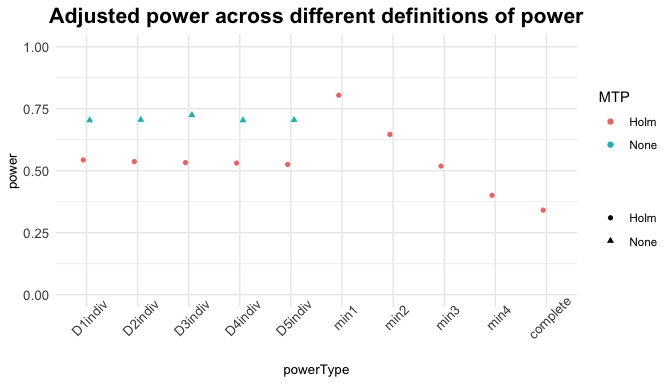

```r
plot( p_check )
```

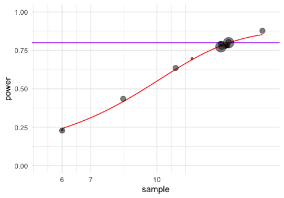

```r
plot_power_curve( smp )
```

## Comparing alternate approaches

The package works with a range of multiple testing procedures and a range of modeling options. In the next two sections we show how to compare these within a given experimental design.

### Comparing adjustment procedures

It is easy to rerun the above using the Westfall-Young Stepdown procedure (this procedure is much more computationally intensive to run), or other procedures of interest. Alternatively, simply provide a list of procedures you wish to compare. If you provide a list, the package will re-run the power calculator for each item on the list; this can make the overall call computationally intensive. Here we obtain power for our scenario using Bonferroni, Holm and Westfall-Young adjustments: m

```r
p2 <- update( p_check, MTP = c("Bonferroni", "Holm", "WY-SD") )
print( p2 )
```

```
#> power result: d3.2_m3fc2rc design with 5 outcomes
#>         MTP D1indiv D2indiv D3indiv D4indiv D5indiv indiv.mean   min1   min2
#>        None  0.7170   0.702  0.6910  0.7000  0.7155     0.7051     NA     NA
#>  Bonferroni  0.4230   0.429  0.4360  0.4205  0.4200     0.4257 0.8170 0.6110
#>        Holm  0.5050   0.520  0.5105  0.4995  0.5095     0.5089 0.7880 0.6415
#>       WY-SD  0.3885   0.388  0.3910  0.3910  0.3915     0.3900 0.7105 0.4935
#>    min3   min4 complete
#>      NA     NA       NA
#>  0.3945 0.2185   0.3265
#>  0.4810 0.3710   0.3075
#>  0.3470 0.2380   0.3180
```

### Comparing modeling choices

In `PUMP` these choices are specified by different `design` arguments. For our context, for example, we could use a random effects model at level three instead of a fixed effects model, setting `design = "d3.2_m3rr2rc"` instead of `"d3.2_m3fc2rc"`; this would target a superpopulation average, viewing the blocks as a random sample, vs. a finite population where the blocks are considered fixed.

Random effects models allow for level three covariates, which we would need to specify via `numCovar.3` and `R2.3` to capture how many there are and how predictive they are:

```r
p3 <- update( p_check, design="d3.2_m3rr2rc", numCovar.3 = 3, R2.3 = 0.40 )
print( p3 )
```

```
#> power result: d3.2_m3rr2rc design with 5 outcomes
#>   MTP D1indiv D2indiv D3indiv D4indiv D5indiv indiv.mean  min1   min2   min3
#>  None  0.6630  0.6525  0.6530   0.648  0.6640     0.6561    NA     NA     NA
#>  Holm  0.3975  0.3970  0.4005   0.392  0.3945     0.3963 0.679 0.4875 0.3525
#>    min4 complete
#>      NA       NA
#>  0.2655    0.272
```

## Exploring sensitivity to design parameters

Given the above, we might wonder how power shifts if we change our design parameters. For some discussion of what parameters will affect power more generally, see @RN4473. For discussion of how design parameters can affect the overall power in the multiple testing context, especially with regards to the overall power measures such as min1 or complete power, see @Porter2018; the findings there are general, as they are a function of the final distribution of test statistics. The key insight into this approach is that power is a function of only a few summarizing elements: the individual-level standard errors, the degrees of freedom, and the correlation structure of the test statistics. Once we have these elements, regardless of the design, we can proceed.

Within the pump package we have two general ways of exploring design sensitivity. The first is with `update()`, which allows for quickly generating alternate scenarios that can each have very specific structure. To explore sensitivity to different design parameters more systematically, use the `grid()` functions, which calculate power, mdes, and sample size for all combinations of a set of passed parameter values. The main difference between the two approaches is the `update()` approach allows for different structures for the different outcomes. The `grid` approach is more limited in this regard, but is still a powerful tool for systematically exploring many possible combinations.

We first illustrate the `update()` approach, and then turn to illustrating `grid()` across three common areas of exploration: Intraclass Correlation Coefficients (ICCs), the correlation of test statistics, and the assumed number of non-zero effects. The last two are particularly important for multiple outcome contexts.

### Exploring power with update()

Update allows for a quick change of some of the set of parameters used in a prior call; we saw `update()` used several times above. As a further example, here we examine what happens if the ICCs are more equally split across levels two and three:

```r
p_b <- update( p_check, ICC.2 = 0.20, ICC.3 = 0.25 )
print( p_b )
```

```
#> power result: d3.2_m3fc2rc design with 5 outcomes
#>   MTP D1indiv D2indiv D3indiv D4indiv D5indiv indiv.mean   min1  min2  min3
#>  None  0.2385  0.2395   0.245  0.2330  0.2350     0.2382     NA    NA    NA
#>  Holm  0.1055  0.0935   0.101  0.0915  0.0985     0.0980 0.2635 0.116 0.061
#>    min4 complete
#>      NA       NA
#>  0.0335    0.025
```

When calculating power for a given scenario, it is also easy to vary many of our design parameters by outcome. For example, if we thought we had better predictive covariates for our second outcome, we might try:

```r
p_d = update( p_check,
            R2.1 = c( 0.1, 0.3, 0.1, 0.2, 0.2 ),
            R2.2 = c( 0.4, 0.8, 0.3, 0.2, 0.2 ),
            omega.3 = c( 0.2, 0.4, 0.3, 0.2, 0.2 ) )
print( p_d )
```

```
#> power result: d3.2_m3fc2rc design with 5 outcomes
#>   MTP D1indiv D2indiv D3indiv D4indiv D5indiv indiv.mean   min1   min2   min3
#>  None  0.4145  0.8435  0.3815  0.3215  0.3240     0.4570     NA     NA     NA
#>  Holm  0.2410  0.6620  0.2035  0.1830  0.1795     0.2938 0.7125 0.3745 0.2085
#>   min4 complete
#>     NA       NA
#>  0.114    0.074
```

Notice how the individual powers are heavily impacted. The min-$d$ powers naturally take the varying outcomes into account as we are calculating a joint distribution of test statistics that will have the correct marginal distributions based on these different design parameter values.

After several `update()`s, we may lose track of where we are; to find out, we can always check details with `print_design()` or `summary()`:

```r
summary(p_d)
```

```
#> power result: d3.2_m3fc2rc design with 5 outcomes
#>   MDES vector: 0.1, 0.1, 0.1, 0.1, 0.1
#>   nbar: 258  J: 3    K: 15   Tbar: 0.5
#>   alpha: 0.05
#>   Level:
#>     1: R2: 0.1 / 0.3 / 0.1 / 0.2 / 0.2 (5 covariate)
#>     2: R2: 0.4 / 0.8 / 0.3 / 0.2 / 0.2 (3 covariate) ICC: 0.05   omega: 0
#>     3:   fixed effects   ICC: 0.4    omega: 0.2 / 0.4 / 0.3 / 0.2 / 0.2
#>   rho = 0.4
#>   MTP D1indiv D2indiv D3indiv D4indiv D5indiv indiv.mean   min1   min2   min3
#>  None  0.4145  0.8435  0.3815  0.3215  0.3240     0.4570     NA     NA     NA
#>  Holm  0.2410  0.6620  0.2035  0.1830  0.1795     0.2938 0.7125 0.3745 0.2085
#>   min4 complete
#>     NA       NA
#>  0.114    0.074
#>  (tnum = 2000)
```

Using update allows for targeted comparison of major choices, but if we are interested in how power changes across a range of options, we can do this more systematically with the `grid()` functions, as we do next.

### Exploring the impact of the ICC

We above saw that the ICC does impact power considerably. We next extend this evaluation by exploring a range of options for both level two and three ICCs, so we can assess whether our power is sufficient across a set of plausible values. The `update_grid()` call makes this straightforward: we pass our baseline scenario along with lists of parameters to additionally explore:

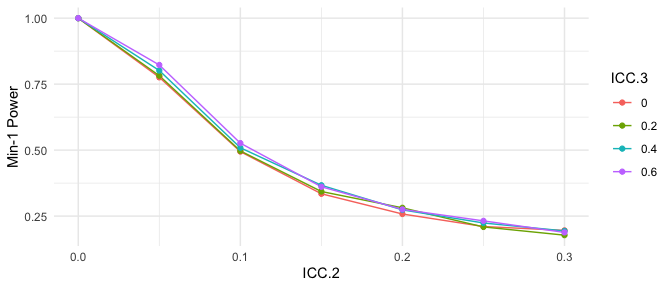

```r
grid <- update_grid( p_check,
            ICC.2 = seq( 0, 0.3, 0.05 ),
            ICC.3 = seq( 0, 0.60, 0.20 ),
            tnum = 5000 )

grid$ICC.3 = as.factor( grid$ICC.3 )
grid = filter( grid, MTP == "Holm" )
ggplot( grid, aes( ICC.2, min1, group = ICC.3, col = ICC.3 ) ) +
    geom_line() + geom_point() +
    labs( y = "Min-1 Power" )
```

We see that higher ICC.2 radically reduces power to detect anything and ICC.3 does little. To understand why, we turn to our standard error formula for this design and model:
$$\begin{aligned}
SE( \hat{\tau} ) = \sqrt{
\frac{\text{ICC}_{2}(1 - R^2_{2})}{\bar{T}(1 - \bar{T}) JK} +
\frac{(1-\text{ICC}_{2} - \text{ICC}_{3})(1-R^2_{1})}{\bar{T}(1 - \bar{T}) J K\bar{n}} } .
\end{aligned}$$
In the above, the $\bar{n} = 258$ students per group makes the second term very small compared to the first regardless of the ICC.3 value. The first term, however, is a direct scaling of ICC.2; changing it will change the standard error, and therefore power, a lot. All provided designs and models implemented in the package are discussed, along with corresponding formula such as these, in our technical supplement accompanying this paper and package.

For grid searches we recommend reducing the number of permutations (here to 5000 via `tnum`) to speed up computation. As `tnum` shrinks, we will get increasingly rough estimates of power, but even these rough estimates can help us determine trends.

The `grid()` functions provide easy and direct ways of exploring how power changes as a function of the design parameters. We note, however, that in order to keep syntax simple, they do not allow different design parameters, including MDES, by outcome. This is to keep package syntax simpler. When faced with contexts where it is believed that these parameters do vary, we recommend using average values for the broader searches, and then double-checking a small set of potential final designs with the `pump_power()` method.

### Exploring the impact of rho

```r
grid <- update_grid( p_check,
            MTP = c( "Bonferroni", "WY-SS" ),
            rho = c( 0, 0.15, 0.3, 0.45, 0.6 ),
            tnum = 500,
            B = 10000 )
```

We then plot our results

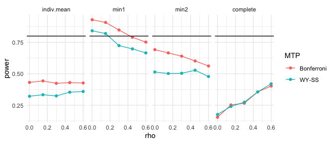

```r
gridL = filter( grid, MTP != "None" ) %>%
  pivot_longer( cols=c(indiv.mean, min1, min2, complete),
                names_to="definition", values_to="power" ) %>%
  mutate( definition = factor( definition,
                            levels = c("indiv.mean", "min1", "min2", "complete" ) ) )

ggplot( gridL, aes( rho, power, col=MTP ) ) +
  facet_grid( . ~ definition ) +
  geom_line() + geom_point() +
  geom_hline( yintercept =0.80 ) + theme_minimal()
```

### Exploring the impact of null outcomes

We finally explore varying the number of outcomes with no effects. This exploration is an important way to hedge a design against the possibility that some number of the identified outcomes are measured poorly, or are simply not impacted by treatment. We use a grid search, varying the number of outcomes that have no treatment impact via the `numZero` design parameter:

```r
grid <- update_grid( p_check,
            numZero = 0:4,
            M = 5 )
```

We then can make a plot as we did above:

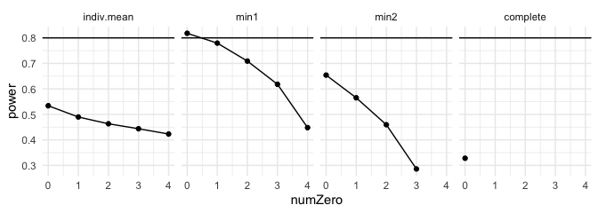

There are other ways of exploring the impact of weak or null effects on some outcomes. In particular, the `pump_power()` and `pump_sample()` methods allow the researcher to provide an MDES vector with different values for each outcome, including 0s for some outcomes. The `grid()` functions, by contrast, take a single MDES value for the non-null outcomes, with a separate specification of how many of the outcomes are 0. (This single value plus `numZero` parameter also works with `pump_power()` if desired.)